# Tennis Data

Neema

September 9, 2019

# Clear the global environment

- Clearing the enviorment before start of programming to free up RAM space

```r
rm(list = ls())
```

# Agenda

- Get the data
- Data Pre-processing
- Build a model
- Classification predictions
- Results/Metrics

# Reading and Understanding the Data

## Data Domain and Format

- The data given is a .csv file.
- Train and test datasets are given separately.
- Read in the data using the “read.csv()” function.

*We have to make sure the dataset is located in our current working directory, else we can change our working directory using the “setwd()” function

```r
setwd("D:/insofe/7305 cute")
```

- To get the current working directory

```r
getwd()
```

```
## [1] "D:/insofe/7305 cute"
```

- Load the Dataset given.

```r
tennis_data = read.csv("train-1542197608821.csv", header = TRUE) # reading the data from which we create models
```

## Data Description

*The given problem is a tennis dataset which is a classification problem.Every tennis match is made up of a sequence of points. A point begins with a serve and players exchange shots until a player makes an error or is unable to return a shot in play.

- Problem Statement:

*We need to classify the player into one of the following three categories : Winner,Unforced error,Forced error.* Winner Description: A winner is a shot that was in play, not touched by the opponent, and ends with the point going to the player who made the shot *The other two categories are two distinct types of errors where both end with the point going to the player who did not make the shot.

- The dataset has the following attributes:

**Response Variable (desired target):** 1 - Outcome W - Winner FE - Forced Error UE - Unforced Error

**Other Variable (Feature attributes):**  
2 - Rally: is a collective name given to a sequence of back and forth shots between players, within a point. 3 - Serve: The starting stroke of each point. The ball must be hit into the opponent’s service box. 4 - Depth: depth will force your opponent to hit one or two additional shots during every point, which will often lead them to make errors. 5 - Gender: Male or Female 6 - ID: ID of data points 7 - Previous.speed: speed of the previous serve

# Understanding the data/ EDA (Exploratory Data Analysis)

- We use head() and tail() function to get the first 6 rows of the given dataset

```r
head(tennis_data)
```

```
##   rally serve hitpoint    speed net.clearance distance.from.sideline
## 1     4     1        B 35.51504   -0.02172454              3.4747658
## 2     4     2        B 33.38264    1.11420238              2.5408011
## 3    23     1        B 22.31669   -0.25404611              3.5331663
## 4     9     1        F 36.83731    0.76669374              0.5868845
## 5     4     1        B 35.54421    0.11616188              0.9187249
## 6    10     1        B 39.01219    0.34988868              0.4850978
##      depth outside.sideline outside.baseline player.distance.travelled
## 1 6.797621            FALSE            FALSE                 1.4675701
## 2 2.608708            FALSE             TRUE                 2.3119314
## 3 9.435749            FALSE            FALSE                 3.9037281
## 4 3.342180             TRUE            FALSE                 0.5837453
## 5 5.499119            FALSE            FALSE                 2.3334559
## 6 3.264708             TRUE            FALSE                 0.8043375
##   player.impact.depth player.impact.distance.from.center player.depth
```

[output cut: 34 more lines]

- To get the last 6 rows of the given dataset

```r
tail(tennis_data)
```

```
##      rally serve hitpoint    speed net.clearance distance.from.sideline
## 7996     4     1        F 28.31305   -0.07847376              3.2230977
## 7997     4     2        F 36.69320    0.18610107              0.4576697
## 7998     5     2        B 33.50532    0.98503211              2.7674060
## 7999    10     2        F 16.90629    0.67440102              0.5250427
## 8000     6     2        F 15.19971    0.93601542              3.3658397
## 8001     3     1        F 30.67954   -0.03367366              2.3247433
##          depth outside.sideline outside.baseline player.distance.travelled
## 7996 7.4667592            FALSE            FALSE                  4.869239
## 7997 4.0269655            FALSE            FALSE                  3.068317
## 7998 0.2755693            FALSE             TRUE                  3.747929
## 7999 2.0052568            FALSE            FALSE                  7.931349
## 8000 1.4593775            FALSE            FALSE                 11.454605
## 8001 6.2688534            FALSE            FALSE                  1.795455
##      player.impact.depth player.impact.distance.from.center player.depth
```

[output cut: 34 more lines]

- Use the str(), summary() functions to get the dimensions and type of attributes in the dataset.
- Verify the data types assigned to the variables in the dataset

```r
str(tennis_data)
```

```
## 'data.frame':    8001 obs. of  27 variables:
##  $ rally                             : int  4 4 23 9 4 10 7 3 11 20 ...
##  $ serve                             : int  1 2 1 1 1 1 1 1 2 1 ...
##  $ hitpoint                          : Factor w/ 4 levels "B","F","U","V": 1 1 1 2 1 1 1 2 2 2 ...
##  $ speed                             : num  35.5 33.4 22.3 36.8 35.5 ...
##  $ net.clearance                     : num  -0.0217 1.1142 -0.254 0.7667 0.1162 ...
##  $ distance.from.sideline            : num  3.475 2.541 3.533 0.587 0.919 ...
##  $ depth                             : num  6.8 2.61 9.44 3.34 5.5 ...
##  $ outside.sideline                  : logi  FALSE FALSE FALSE TRUE FALSE TRUE ...
##  $ outside.baseline                  : logi  FALSE TRUE FALSE FALSE FALSE FALSE ...
##  $ player.distance.travelled         : num  1.468 2.312 3.904 0.584 2.333 ...
##  $ player.impact.depth               : num  14.2 12.7 15.4 13.7 15.2 ...
##  $ player.impact.distance.from.center: num  1.1448 4.6258 1.4336 0.0312 1.7596 ...
##  $ player.depth                      : num  13.7 12.6 13.7 13.1 14.1 ...
##  $ player.distance.from.center       : num  0.233 2.3162 2.0908 0.0188 0.315 ...
##  $ previous.speed                    : num  32.3 34.1 39.8 25 36.8 ...
##  $ previous.net.clearance            : num  1.351 0.76 0.378 1.239 0.166 ...
##  $ previous.distance.from.sideline   : num  2.449 0.583 1.115 3.257 1.431 ...
##  $ previous.depth                    : num  0.705 3.857 2.909 0.558 3.945 ...
##  $ opponent.depth                    : num  12.6 12.4 13.9 14.3 11.4 ...
##  $ opponent.distance.from.center     : num  2.072 5.112 1.656 0.161 1.108 ...
##  $ same.side                         : logi  TRUE FALSE FALSE TRUE FALSE TRUE ...
##  $ previous.hitpoint                 : Factor w/ 4 levels "B","F","U","V": 2 1 2 1 2 2 2 2 4 2 ...
##  $ previous.time.to.net              : num  0.445 0.432 0.398 0.672 0.34 ...
##  $ server.is.impact.player           : logi  FALSE FALSE TRUE TRUE FALSE FALSE ...
##  $ outcome                           : Factor w/ 3 levels "FE","UE","W": 2 1 1 2 3 2 2 3 2 3 ...
##  $ gender                            : Factor w/ 2 levels "mens","womens": 1 1 1 1 1 1 1 1 1 1 ...
##  $ ID                                : int  8644 1182 9042 1222 4085 292 9288 9774 2615 2357 ...
```

** This Dataset has 8001 observations and 27 variables. ** The outcome column is the target variable to predict.

```r
summary(tennis_data)
```

```
##      rally            serve       hitpoint     speed
##  Min.   : 3.000   Min.   :1.000   B:3034   Min.   : 5.176
##  1st Qu.: 3.000   1st Qu.:1.000   F:4402   1st Qu.:26.770
##  Median : 5.000   Median :1.000   U: 429   Median :32.418
##  Mean   : 5.966   Mean   :1.399   V: 136   Mean   :30.807
##  3rd Qu.: 7.000   3rd Qu.:2.000            3rd Qu.:35.681
##  Max.   :38.000   Max.   :2.000            Max.   :55.053
##  net.clearance      distance.from.sideline     depth
##  Min.   :-0.99818   Min.   :0.000497       Min.   : 0.003135
##  1st Qu.:-0.02709   1st Qu.:0.539500       1st Qu.: 1.641161
##  Median : 0.44587   Median :1.210847       Median : 3.860266
##  Mean   : 0.62966   Mean   :1.467630       Mean   : 4.421146
##  3rd Qu.: 0.97084   3rd Qu.:2.215955       3rd Qu.: 7.029345
##  Max.   :12.81589   Max.   :7.569757       Max.   :11.886069
##  outside.sideline outside.baseline player.distance.travelled
##  Mode :logical    Mode :logical    Min.   : 0.000
##  FALSE:6500       FALSE:6380       1st Qu.: 1.444
##  TRUE :1501       TRUE :1621       Median : 2.361
##                                    Mean   : 2.690
##                                    3rd Qu.: 3.566
##                                    Max.   :14.481
##  player.impact.depth player.impact.distance.from.center  player.depth
##  Min.   : 2.156      Min.   :0.0002                     Min.   : 1.39
##  1st Qu.:11.221      1st Qu.:0.9424                     1st Qu.:11.37
##  Median :12.692      Median :1.8294                     Median :12.55
##  Mean   :11.900      Mean   :1.9195                     Mean   :12.25
##  3rd Qu.:13.553      3rd Qu.:2.7452                     3rd Qu.:13.50
##  Max.   :18.126      Max.   :7.7462                     Max.   :18.75
##  player.distance.from.center previous.speed   previous.net.clearance
##  Min.   :0.0004              Min.   : 8.449   Min.   :0.02886
##  1st Qu.:0.5518              1st Qu.:24.033   1st Qu.:0.40481
##  Median :0.9838              Median :29.793   Median :0.65838
##  Mean   :1.2138              Mean   :28.764   Mean   :0.82156
##  3rd Qu.:1.5966              3rd Qu.:33.581   3rd Qu.:1.02140
##  Max.   :9.3526              Max.   :54.208   Max.   :6.73027
##  previous.distance.from.sideline previous.depth     opponent.depth
##  Min.   :0.000164                Min.   :0.000467   Min.   : 2.161
##  1st Qu.:1.354458                1st Qu.:2.733674   1st Qu.:12.082
##  Median :2.168822                Median :4.126864   Median :12.902
##  Mean   :2.193420                Mean   :4.218717   Mean   :12.617
```

[output cut: 8 more lines]

```
##  Max.   :6.8526
##  previous.time.to.net server.is.impact.player outcome      gender
##  Min.   :0.003201     Mode :logical           FE:1818   mens  :4005
##  1st Qu.:0.432164     FALSE:3331              UE:3501   womens:3996
##  Median :0.507559     TRUE :4670              W :2682
##  Mean   :0.549988
##  3rd Qu.:0.624135
##  Max.   :1.635257
##        ID
##  Min.   :    1
##  1st Qu.: 2500
##  Median : 4996
##  Mean   : 5005
##  3rd Qu.: 7523
##  Max.   :10000
```

# Data Pre-Processing

## Missing values

- Verify if the dataset has missing values

```r
sum(is.na(tennis_data))
```

```
## [1] 0
```

```r
colSums(is.na(tennis_data))
```

```
##                              rally                              serve
##                                  0                                  0
##                           hitpoint                              speed
##                                  0                                  0
##                      net.clearance             distance.from.sideline
##                                  0                                  0
##                              depth                   outside.sideline
##                                  0                                  0
##                   outside.baseline          player.distance.travelled
##                                  0                                  0
##                player.impact.depth player.impact.distance.from.center
##                                  0                                  0
##                       player.depth        player.distance.from.center
##                                  0                                  0
##                     previous.speed             previous.net.clearance
##                                  0                                  0
##    previous.distance.from.sideline                     previous.depth
##                                  0                                  0
##                     opponent.depth      opponent.distance.from.center
##                                  0                                  0
##                          same.side                  previous.hitpoint
##                                  0                                  0
##               previous.time.to.net            server.is.impact.player
##                                  0                                  0
##                            outcome                             gender
##                                  0                                  0
##                                 ID
##                                  0
```

- It shows that no null values is present

## To check the column names

- To get the column names of the given dataset.

```r
colnames(tennis_data)
```

```
##  [1] "rally"
##  [2] "serve"
##  [3] "hitpoint"
##  [4] "speed"
##  [5] "net.clearance"
##  [6] "distance.from.sideline"
##  [7] "depth"
##  [8] "outside.sideline"
##  [9] "outside.baseline"
## [10] "player.distance.travelled"
## [11] "player.impact.depth"
## [12] "player.impact.distance.from.center"
## [13] "player.depth"
## [14] "player.distance.from.center"
## [15] "previous.speed"
## [16] "previous.net.clearance"
## [17] "previous.distance.from.sideline"
## [18] "previous.depth"
## [19] "opponent.depth"
## [20] "opponent.distance.from.center"
## [21] "same.side"
## [22] "previous.hitpoint"
## [23] "previous.time.to.net"
## [24] "server.is.impact.player"
## [25] "outcome"
## [26] "gender"
## [27] "ID"
```

## Converting attributes

- Converting the attributes into into appropriate data types

```r
attr = colnames(tennis_data)
cat_attr = c("serve", "hitpoint", "outside.sideline", "outside.baseline", "same.side", "previous.hitpoint", "server.is.impact.player", "outcome", "gender")
num_attr = setdiff(attr,cat_attr)
cat_data = data.frame(sapply(tennis_data[,cat_attr],as.factor))
num_data = data.frame(sapply(tennis_data[,num_attr],as.character))
num_data = data.frame(sapply(tennis_data[,num_attr],as.numeric))
tennis_data = cbind(num_data,cat_data)
```

## Dropping columns

- ID column is not relevant

```r
tennis_data$ID = NULL

str(tennis_data)
```

```
## 'data.frame':    8001 obs. of  26 variables:
##  $ rally                             : num  4 4 23 9 4 10 7 3 11 20 ...
##  $ speed                             : num  35.5 33.4 22.3 36.8 35.5 ...
##  $ net.clearance                     : num  -0.0217 1.1142 -0.254 0.7667 0.1162 ...
##  $ distance.from.sideline            : num  3.475 2.541 3.533 0.587 0.919 ...
##  $ depth                             : num  6.8 2.61 9.44 3.34 5.5 ...
##  $ player.distance.travelled         : num  1.468 2.312 3.904 0.584 2.333 ...
##  $ player.impact.depth               : num  14.2 12.7 15.4 13.7 15.2 ...
##  $ player.impact.distance.from.center: num  1.1448 4.6258 1.4336 0.0312 1.7596 ...
##  $ player.depth                      : num  13.7 12.6 13.7 13.1 14.1 ...
##  $ player.distance.from.center       : num  0.233 2.3162 2.0908 0.0188 0.315 ...
##  $ previous.speed                    : num  32.3 34.1 39.8 25 36.8 ...
##  $ previous.net.clearance            : num  1.351 0.76 0.378 1.239 0.166 ...
##  $ previous.distance.from.sideline   : num  2.449 0.583 1.115 3.257 1.431 ...
##  $ previous.depth                    : num  0.705 3.857 2.909 0.558 3.945 ...
##  $ opponent.depth                    : num  12.6 12.4 13.9 14.3 11.4 ...
##  $ opponent.distance.from.center     : num  2.072 5.112 1.656 0.161 1.108 ...
##  $ previous.time.to.net              : num  0.445 0.432 0.398 0.672 0.34 ...
##  $ serve                             : Factor w/ 2 levels "1","2": 1 2 1 1 1 1 1 1 2 1 ...
##  $ hitpoint                          : Factor w/ 4 levels "B","F","U","V": 1 1 1 2 1 1 1 2 2 2 ...
##  $ outside.sideline                  : Factor w/ 2 levels "FALSE","TRUE": 1 1 1 2 1 2 1 1 1 1 ...
##  $ outside.baseline                  : Factor w/ 2 levels "FALSE","TRUE": 1 2 1 1 1 1 2 1 2 1 ...
##  $ same.side                         : Factor w/ 2 levels "FALSE","TRUE": 2 1 1 2 1 2 1 1 1 2 ...
##  $ previous.hitpoint                 : Factor w/ 4 levels "B","F","U","V": 2 1 2 1 2 2 2 2 4 2 ...
##  $ server.is.impact.player           : Factor w/ 2 levels "FALSE","TRUE": 1 1 2 2 1 1 2 2 2 1 ...
##  $ outcome                           : Factor w/ 3 levels "FE","UE","W": 2 1 1 2 3 2 2 3 2 3 ...
##  $ gender                            : Factor w/ 2 levels "mens","womens": 1 1 1 1 1 1 1 1 1 1 ...
```

## Class imbalance

```r
#tennis_data
table(tennis_data$outcome) # FE:UE:W is 1818:3501:2682 whish seems to be acceptable
```

```
##
##   FE   UE    W
## 1818 3501 2682
```

# Data Visualization

## We use boxplot to see the outliers

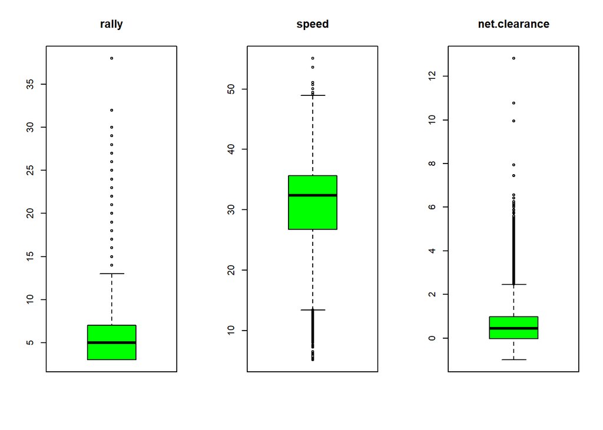

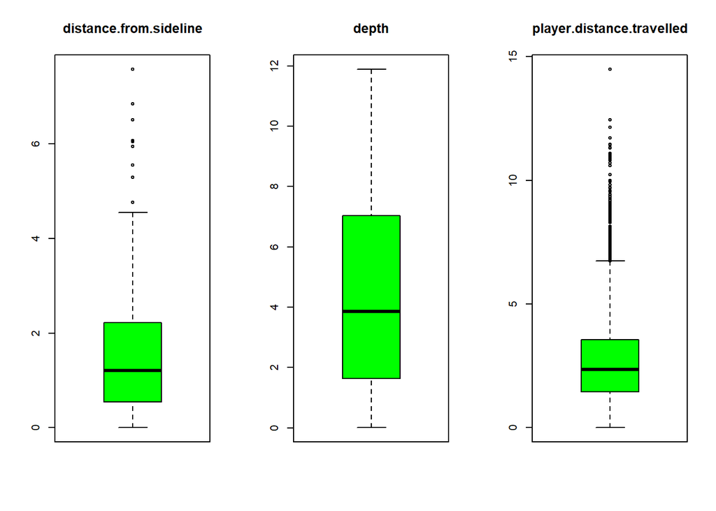

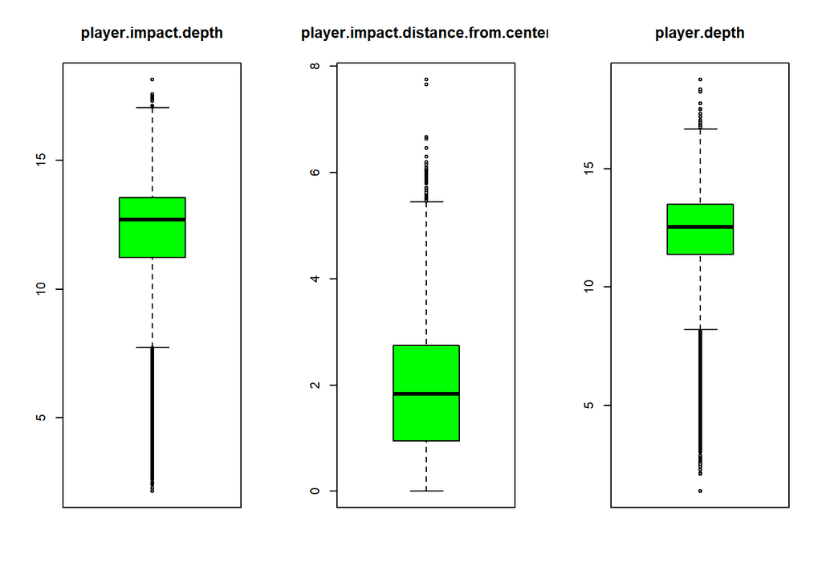

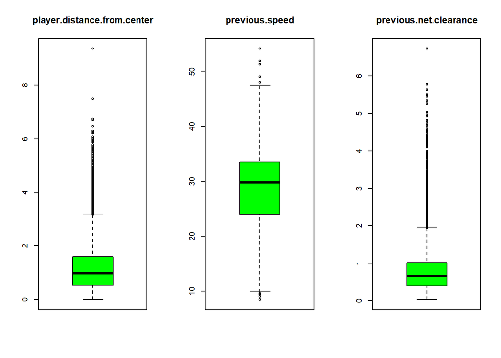

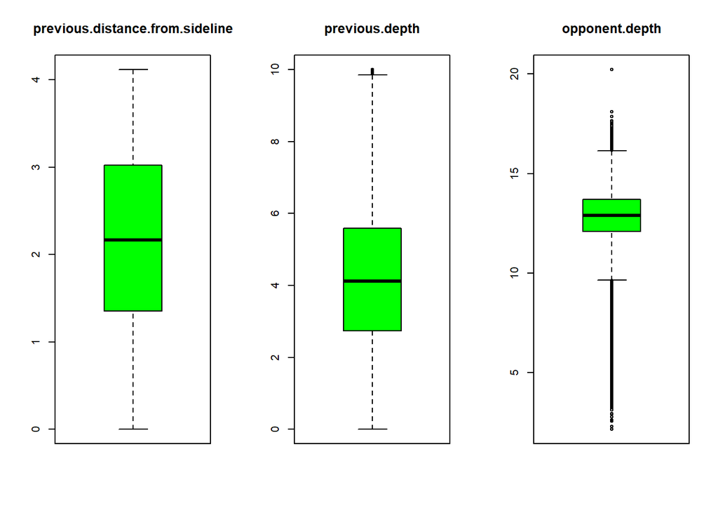

```r
par(mfrow=c(1,3))
for(i in 1:17)
  {
  boxplot(tennis_data[,i], main=names(tennis_data)[i],col="green")
}
```

```r
#Any dots outside the whiskers are good candidates for outliers.
```

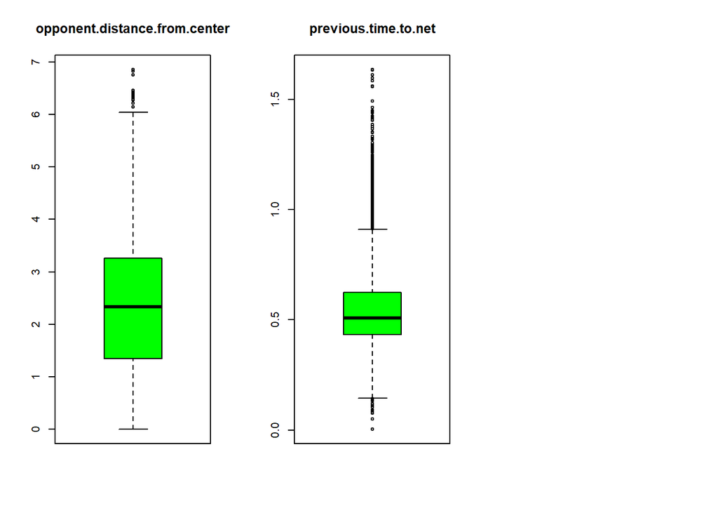

## Correlation Plot

- Checking for correlations between the variables in the dataset

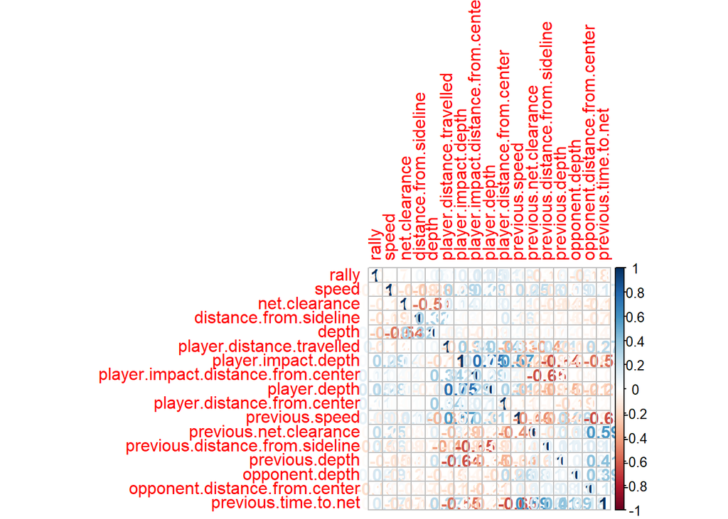

```r
library(corrplot)
corrplot(cor(tennis_data[,1:17], use = "complete.obs"), method = "number")
```

```r
# the correlation between each pair of numeric variables. These pair-wise correlations can be plotted in a correlation matrix plot to given an idea of which variables change together.
# if we use complete.obs then missing values are handled by case wise deletion, number method gives the correlation coefficient in form of number, we can also use circle,elipse..
```

## Exploring a few bi-variate relationships between columns

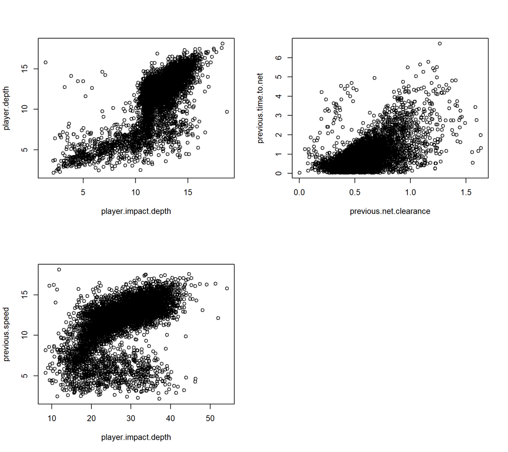

```r
par(mfrow = c(2,2))
plot(tennis_data$player.depth, tennis_data$player.impact.depth, ylab = "player.depth", xlab = "player.impact.depth")
plot(tennis_data$previous.time.to.net, tennis_data$previous.net.clearance, ylab = "previous.time.to.net", xlab = "previous.net.clearance")
plot(tennis_data$previous.speed, tennis_data$player.impact.depth, ylab = "previous.speed", xlab = "player.impact.depth")
```

# Split the data into Train and Test

- We split the data 70/30 into train and test sets
- Setting the seed as “789”

```r
set.seed(789)

train_row = sample(1:nrow(tennis_data), nrow(tennis_data)*0.7)
train_data = tennis_data[train_row,] #subsetting tennis_data data into train_data
test_data = tennis_data[-train_row,] ##subsetting tennis_data data into test_data
```

# Build the classification model by using RandomForest

- Build the model by using RandomForest.
- Here we are using randomForest library

```r
library(randomForest)
model = randomForest(outcome~., data = train_data, keep.forest=TRUE, ntree=50)
```

# View results and understand important attributes

## Print and understand the model

- It gives the idea about the model
- The number of trees used here is 50
- Number of variables tried at each split is 5 (by default).
- Error rate is 14.16

```r
print(model)
```

```
##
## Call:
##  randomForest(formula = outcome ~ ., data = train_data, keep.forest = TRUE,      ntree = 50)
##                Type of random forest: classification
##                      Number of trees: 50
## No. of variables tried at each split: 5
##
##         OOB estimate of  error rate: 14.16%
## Confusion matrix:
##     FE   UE    W class.error
## FE 888  326   42  0.29299363
## UE 227 2163   87  0.12676625
## W   45   66 1756  0.05945367
```

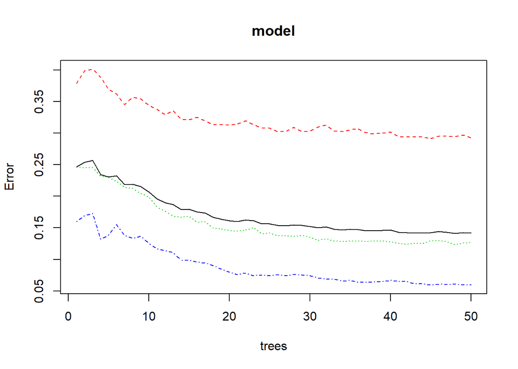

```r
plot(model)
```

# Important attributes

- It gives the important attributes using Gini Index

```r
#model$importance
round(importance(model), 2) #It round upto 2 decimal
```

```
##                                    MeanDecreaseGini
## rally                                         38.13
## speed                                        216.74
## net.clearance                                555.42
## distance.from.sideline                       173.72
## depth                                        218.99
## player.distance.travelled                    127.73
## player.impact.depth                          212.23
## player.impact.distance.from.center            80.06
## player.depth                                  92.47
## player.distance.from.center                   72.33
## previous.speed                               189.54
## previous.net.clearance                       106.38
## previous.distance.from.sideline              175.41
## previous.depth                               116.16
## opponent.depth                               144.74
## opponent.distance.from.center                 77.27
## previous.time.to.net                         278.23
## serve                                          8.21
## hitpoint                                      25.44
## outside.sideline                             362.29
## outside.baseline                             274.33
## same.side                                      6.84
## previous.hitpoint                             32.54
## server.is.impact.player                        7.36
## gender                                         8.58
```

# Extract and store important variables obtained from the random forest model

- Extracting the important variables from the random forest model and store that variables also

```r
rf_imp_attr = data.frame(model$importance)
rf_imp_attr = data.frame(row.names(rf_imp_attr),rf_imp_attr[,1])
colnames(rf_imp_attr) = c('attributes', 'importance')
rf_imp_attr = rf_imp_attr[order(rf_imp_attr$importance, decreasing = TRUE),]
```

# Plot important attributes

- Here we are plotting the graph according to the Gini Index values

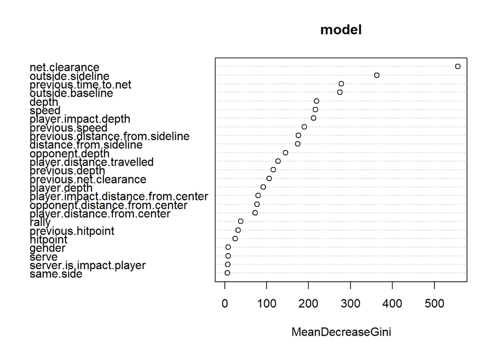

```r
varImpPlot(model)
```

# Predict on Train and Test datasets and calculate accuracy

## Predict on Train data

- Prediction on the Train data

```r
pred_Train = predict(model,train_data[,setdiff(names(train_data),"outcome")],type="response", norm.votes=TRUE)# norm.votes has values True or false, if true votes will be normalized.
# type has values response,prob or votes. response:predicted values
pred_Train
```

```
## 5600  748   96 4732 3936  162 4579 1326 2869 2768 2510 4055 2019 3722 3441
##   UE   FE   UE    W   UE   UE    W   FE   UE   FE   UE    W   UE    W    W
##  147 1246 5152 6149  888 2744 3570 1261 2419 3426 4127 2495 3958 6564 4009
##   UE   UE   UE   UE    W   UE   UE    W    W   UE   UE   UE    W   UE   UE
## 1749 2214 5290 3902 2167 3477 4643 2251 1740 5901 1922 6270 5992 7943 1556
##   FE    W   FE   UE    W    W   UE    W    W   UE   FE   UE   FE    W   FE
## 1311 5119 7329  608 5927 7978  290 3135 7380 3347 7312 6390 4364 3446 2343
##   FE   UE   FE   FE   UE   UE    W   UE    W   FE    W    W   UE    W   UE
## 2808 5594 1018 5297 5785 5955 5668 6051 1832 2284 1150 6153  744 1432 3322
##    W   UE   UE    W   UE   UE   UE   UE   UE   FE   UE   UE   UE    W   UE
## 3162 2170 4010 5908 7010 3443 4593 7609 6419 7494 2602 6246 6568 7099  637
##   UE    W    W   FE   FE   UE   UE   UE    W   FE   UE   UE    W   UE   UE
## 5501  912    8  167 5396 2062 5805 4481 6613 2143 3801 2482  508 7032 6213
##   UE   FE    W   UE   UE   UE   FE    W    W   FE   UE   FE    W    W   UE
## 1292 3495 3388 1894 3794 5755 4951 6793 3408 1881  918 6909 2977 7030 5098
##    W   UE    W    W   UE   FE   UE   FE    W   UE    W   UE   UE    W   UE
## 2944 7783 6053 5595 3048 6566 7801 6007 5007 1297 2872 4934 1443 1937 2729
##   UE    W   UE   FE   FE   UE   UE   UE   UE   FE   FE   UE    W   UE   UE
## 6166 1318 5694 6127  489 5558 4536 6705 4468 6942 2943 2888  243 1140  577
##    W   UE   UE   UE    W   UE   UE   UE    W    W    W   UE    W    W   FE
## 3108 5767 7327 3623 6157  255 7890 1795  407 4642 7589 5960 5351 4207 1268
##   UE   UE   FE    W   UE   UE    W   UE   UE   FE   UE    W   FE   UE    W
## 4916 4709  973  620 3831 4190 5837 4882 4995 2587 6148  576 2283 7098 5750
##   FE   FE   FE   FE    W   FE   UE   UE   FE    W    W    W   FE   UE   UE
## 2475 5189 6676 6691 1618 2022  999  750   35 6158 6545 1962 4519 4236 2081
##    W   UE   UE    W    W   FE   UE   UE   UE   UE   UE    W   UE   UE   UE
## 1413 5258 3074 7281 2244 7824  730 2691 1680 5621 7227 4405 6478 4334  898
##    W   UE   UE    W   FE    W   FE    W   FE   FE   UE    W    W   UE   UE
## 5581 7293 5923 5534 1098 1074 5865 2883 3348 4559 4625   99  196 4535   12
##   UE    W   UE   UE   UE   UE   UE   UE   FE    W   UE    W   UE   UE   UE
## 6164 5921 6417 2822 7882 6275 3386 5051 2280 1666 4070 4920 1837 7116 6385
##    W   FE    W   UE   UE   UE    W   UE   FE   UE   FE    W    W   FE    W
## 1621 3912 4984 3726 5116 6743 6451 6184 3258 3297 5536 6664 5176 4633 3917
##   UE    W   UE   FE   UE   UE    W   UE    W    W    W   FE   UE    W   UE
## 7495 3513 6713 4782 2188  766 5210 5368 2812  483 6525 4534 1678 3920  186
##   UE   UE   UE   UE   FE   UE    W   FE    W   UE   FE   UE   UE   FE   UE
##  181 6929 1826  388 5522 5407 3669 6595 7715  250 1012 7180  262 7109 3485
##   UE   UE   FE    W   FE   FE   UE    W   UE   UE    W   UE   UE   UE   UE
## 6633 5583 1840 3053 3751 1611 7547 5358 2726 6807 2425 7459 5364 1942 7295
##    W    W   UE   FE   FE    W   FE   UE   UE   FE   FE   UE   UE    W   UE
```

[output cut: 694 more lines]

```
## 7746 6506 2853 3436 2588  682 6445 7596 5028 7702 7250 6917 1396 5977 1032
##   UE   UE    W    W    W    W   UE   FE   UE   UE   UE   UE    W   FE   UE
## 1058  405  129 4816  679 5848 6859  555 2821 5787 3990 2881 4997  157 2250
##   UE   UE   FE   FE   UE   UE   UE   UE   UE   UE   FE   UE   FE   FE   FE
##  715 7218 6279 6065 1784 2304 7959 5678 3886 2243 3728 1668 4370 5039 7215
##   UE   FE   UE   UE   FE    W   FE   UE    W   UE    W   UE    W    W   UE
## 6002 1761 4795 2546 6750 2967  944 5571 2623 6957 7663 6653 6754 5327 5491
##   UE    W   FE   FE    W   FE   FE    W    W   FE   FE   UE   FE   UE   FE
## 2373 4908 2709 4783  142 4354  859  161 7287 3351 5753 2852 4447 7291 1254
##   UE   UE   UE    W   FE   UE   FE   UE   FE   FE   UE   UE    W   UE   FE
## 4013 4366 4976 1834  125 4104 6922 6689 7808 1841 2346  854 5253 3467 4805
##   UE   UE   FE   UE   UE   UE   FE   UE    W   FE    W   UE   UE    W   FE
## 4302 2166 6410 5222  611
##   FE   UE   FE    W   UE
## Levels: FE UE W
```

## Build confusion matrix and find accuracy

*Build the confusion matrix and check the accuracy of the model in train data

```r
cm_train = table("actual" = train_data$outcome, "predicted" = pred_Train);
accu_train_imp = sum(diag(cm_train))/sum(cm_train)
accu_train_imp
```

```
## [1] 0.9998214
```

## Predict on test data

- Prediction on the test data

```r
pred_Test = predict(model,test_data[,setdiff(names(test_data),"outcome")],type = "response", norm.votes=TRUE) # norm.votes has values True or false, if true votes will be normalized.
# type has values response,prob or votes. response:predicted values
pred_Test
```

```
##    3    5   13   15   16   24   26   27   30   31   38   42   43   45   48
##   FE    W   UE   UE   FE   FE   UE   UE    W   UE   UE   UE   FE    W   UE
##   49   52   55   60   63   64   65   68   79   80   81   83   90   93  105
##    W    W   FE   UE   FE   UE   UE   UE   FE   UE    W   UE   FE    W   UE
##  106  109  114  123  127  135  138  144  150  152  154  155  156  158  160
##   FE    W   UE   UE   UE    W   UE    W    W    W    W   FE   UE    W   UE
##  165  166  169  170  172  176  178  180  187  189  190  191  198  206  208
##    W    W   UE   FE   FE   FE   FE   FE    W    W   UE   UE   UE   UE    W
##  213  214  220  223  226  233  234  236  246  247  251  256  258  266  267
##    W   FE    W    W   UE   UE   FE    W   FE    W    W   UE   UE   UE   UE
##  270  276  278  284  289  293  296  298  301  306  307  308  309  312  316
##    W   UE   FE    W   UE   UE    W   UE   UE   UE    W   UE   UE   UE   UE
##  317  325  326  328  329  330  331  332  334  335  337  344  345  349  353
##    W    W   UE   FE   UE    W    W   FE    W   FE    W   UE   FE    W   FE
##  354  361  364  377  379  381  382  391  398  401  404  410  415  426  427
##   FE   FE   UE    W   FE   FE   UE   FE   UE   FE   UE   UE   FE    W    W
##  430  431  438  440  441  447  448  450  451  457  459  462  467  470  471
##   UE   UE   FE    W   UE   FE    W   UE   FE    W   FE   UE    W   UE    W
##  472  475  484  486  488  490  493  497  502  503  513  514  517  518  519
##   FE    W    W    W   UE   FE   FE    W    W   UE   FE   FE   FE    W    W
##  523  526  527  530  531  534  536  542  551  552  554  559  575  587  588
##   UE    W   FE   UE   FE    W    W   UE    W   UE    W   UE   UE   UE   UE
##  593  594  596  600  602  603  604  605  613  614  618  622  625  626  627
##   FE    W   UE   FE   UE   UE   UE    W    W    W   UE    W   UE   UE    W
##  633  634  642  646  648  653  655  661  664  667  672  673  674  675  677
##   UE   UE    W    W   UE   FE    W    W    W    W    W   FE   FE   UE    W
##  685  691  692  693  696  697  698  704  707  711  719  721  727  731  732
##   UE   UE   FE    W    W   FE   FE    W   UE   UE   UE   UE   FE    W    W
##  734  735  740  741  749  752  756  758  764  769  772  776  779  781  782
##   UE   FE   UE   UE    W   UE   UE    W    W   FE   UE   FE    W   FE    W
##  784  795  797  798  800  801  805  810  811  813  817  819  821  823  825
##    W    W   UE    W    W   FE   FE    W   UE   FE   UE   FE   UE    W   FE
##  827  831  833  835  841  844  846  856  857  858  860  861  864  868  869
##   UE   UE   UE    W   UE    W   UE   FE   FE    W   FE   UE   UE    W    W
##  870  872  873  875  881  883  891  892  894  896  899  909  913  915  916
##    W   UE   FE    W   FE   UE    W   UE   UE   FE    W   FE   FE   FE   UE
##  920  927  935  940  941  945  951  956  958  963  968  972  976  979  982
##   FE   FE   UE    W   UE   FE   UE    W    W   FE    W    W   UE    W   UE
##  984  987  988  989  990  992  994  995 1000 1001 1002 1003 1005 1007 1008
##   UE   UE   UE   UE    W   FE   FE    W    W    W    W    W   FE   UE   UE
```

[output cut: 268 more lines]

```
## 7660 7661 7666 7669 7671 7676 7681 7683 7685 7688 7693 7694 7697 7698 7699
##   UE   UE    W    W    W   UE   UE   UE    W    W   UE   UE   UE   FE   FE
## 7704 7710 7711 7712 7716 7721 7723 7725 7732 7735 7739 7740 7742 7744 7748
##   UE   UE   UE   UE    W   UE   UE    W   UE   UE   UE   FE    W    W    W
## 7750 7752 7759 7771 7776 7780 7784 7788 7791 7798 7799 7805 7806 7807 7815
##   FE   UE    W    W    W    W   FE   FE   FE    W   UE   FE   UE    W    W
## 7820 7822 7823 7833 7835 7838 7842 7845 7849 7851 7856 7865 7867 7869 7870
##   UE   UE    W   UE   UE   UE   UE    W   UE    W   UE   UE   UE   UE   FE
## 7872 7875 7876 7886 7889 7903 7904 7907 7909 7927 7929 7935 7939 7941 7942
##   UE   UE   UE   UE    W   UE    W    W    W    W   FE   UE   UE   FE    W
## 7945 7946 7950 7951 7963 7964 7966 7969 7977 7979 7982 7983 7984 7988 7999
##   FE   FE   FE   FE   UE    W    W   FE   FE   UE    W    W   FE   UE    W
## 8000
##    W
## Levels: FE UE W
```

## Build confusion matrix and find accuracy

*Build the confusion matrix and check the accuracy of the model in test data

```r
cm_test =  table("actual" = test_data$outcome, "predicted" = pred_Test);
accu_test_imp = sum(diag(cm_test))/sum(cm_test)
accu_test_imp
```

```
## [1] 0.8575594
```

# Labelling the unseen data

- Labelling the unseen data for predicting the outcome

```r
unseen_data = read.csv("test-1542197608821.csv", header = T)
```

```r
head(unseen_data) #To get the first 6 rows in unseen data
```

```
##   rally serve hitpoint    speed net.clearance distance.from.sideline
## 1     9     2        F 35.17588    0.04388667             0.09470524
## 2    20     1        F 40.22808   -0.07899680             2.33888101
## 3     4     1        B 33.00792    1.04813889             0.23740851
## 4     7     1        F 36.62897    0.25933063             2.16986110
## 5     3     1        F 32.92131    1.54339502             2.82945537
## 6     7     1        U 13.72406   -0.94700003             1.82181950
##       depth outside.sideline outside.baseline player.distance.travelled
## 1 5.2730917            FALSE            FALSE                  3.046643
## 2 6.5980156            FALSE            FALSE                  3.680105
## 3 1.1745173             TRUE             TRUE                  3.113512
## 4 3.2187959            FALSE            FALSE                  6.598774
## 5 0.7054289            FALSE             TRUE                  3.719087
## 6 0.1133739             TRUE            FALSE                  6.593387
##   player.impact.depth player.impact.distance.from.center player.depth
```

[output cut: 34 more lines]

```r
tail(unseen_data) #To get the last 6 rows in unseen data
```

```
##      rally serve hitpoint    speed net.clearance distance.from.sideline
## 1994     5     2        B 37.00355     0.9060152              0.1124936
## 1995     4     1        B 14.53055     0.2764289              1.5004523
## 1996     3     1        F 34.92155     0.2038522              1.3884381
## 1997     3     1        F 27.25652    -0.2309451              3.8665455
## 1998     5     2        B 34.59530    -0.1217635              0.7170799
## 1999     9     1        F 32.34888     0.7388728              1.3848277
##         depth outside.sideline outside.baseline player.distance.travelled
## 1994 1.608037             TRUE             TRUE                  1.089839
## 1995 9.463120            FALSE            FALSE                  2.086592
## 1996 4.191483             TRUE            FALSE                  1.734653
## 1997 8.082819            FALSE            FALSE                  1.937195
## 1998 6.708898            FALSE            FALSE                  1.186388
## 1999 2.862165            FALSE            FALSE                  3.663212
##      player.impact.depth player.impact.distance.from.center player.depth
```

[output cut: 34 more lines]

```r
str(unseen_data)  #We can see that the data types of each attributes of unseen_data
```

```
## 'data.frame':    1999 obs. of  26 variables:
##  $ rally                             : int  9 20 4 7 3 7 12 4 8 3 ...
##  $ serve                             : int  2 1 1 1 1 1 1 2 2 2 ...
##  $ hitpoint                          : Factor w/ 4 levels "B","F","U","V": 2 2 1 2 2 3 1 1 2 2 ...
##  $ speed                             : num  35.2 40.2 33 36.6 32.9 ...
##  $ net.clearance                     : num  0.0439 -0.079 1.0481 0.2593 1.5434 ...
##  $ distance.from.sideline            : num  0.0947 2.3389 0.2374 2.1699 2.8295 ...
##  $ depth                             : num  5.273 6.598 1.175 3.219 0.705 ...
##  $ outside.sideline                  : logi  FALSE FALSE TRUE FALSE FALSE TRUE ...
##  $ outside.baseline                  : logi  FALSE FALSE TRUE FALSE TRUE FALSE ...
##  $ player.distance.travelled         : num  3.05 3.68 3.11 6.6 3.72 ...
##  $ player.impact.depth               : num  13.86 14.86 15.08 7.35 12.47 ...
##  $ player.impact.distance.from.center: num  2.39 3.17 2.87 3.1 4.03 ...
##  $ player.depth                      : num  13.9 14.8 14.5 13.4 11.3 ...
##  $ player.distance.from.center       : num  0.652 0.509 0.186 0.538 0.494 ...
##  $ previous.speed                    : num  38.9 34.7 37.7 16.5 29.9 ...
##  $ previous.net.clearance            : num  0.4846 0.7527 0.0627 1.3865 1.0791 ...
##  $ previous.distance.from.sideline   : num  1.715 1.312 1.428 0.551 0.543 ...
##  $ previous.depth                    : num  3.24 4.14 5.16 6.99 3.35 ...
##  $ opponent.depth                    : num  13.75 13.59 8.96 12.66 13.06 ...
##  $ opponent.distance.from.center     : num  0.0804 0.2918 1.0526 0.5594 4.3934 ...
##  $ same.side                         : logi  TRUE FALSE TRUE TRUE FALSE FALSE ...
##  $ previous.hitpoint                 : Factor w/ 4 levels "B","F","U","V": 2 2 2 2 2 3 2 2 2 1 ...
##  $ previous.time.to.net              : num  0.416 0.477 0.254 0.98 0.523 ...
##  $ server.is.impact.player           : logi  TRUE FALSE FALSE TRUE TRUE TRUE ...
##  $ gender                            : Factor w/ 2 levels "mens","womens": 1 1 1 1 1 1 1 1 1 1 ...
##  $ ID                                : int  1921 486 5177 4632 2735 6843 7756 3053 9605 5662 ...
```

```r
summary(unseen_data) #checking the central tendencies of the unseen data
```

```
##      rally            serve       hitpoint     speed
##  Min.   : 3.000   Min.   :1.000   B: 754   Min.   : 5.968
##  1st Qu.: 3.000   1st Qu.:1.000   F:1104   1st Qu.:27.097
##  Median : 5.000   Median :1.000   U: 108   Median :32.352
##  Mean   : 5.941   Mean   :1.391   V:  33   Mean   :30.960
##  3rd Qu.: 7.000   3rd Qu.:2.000            3rd Qu.:35.817
##  Max.   :25.000   Max.   :2.000            Max.   :60.414
##  net.clearance      distance.from.sideline     depth
##  Min.   :-0.94700   Min.   : 0.000378      Min.   : 0.000282
##  1st Qu.:-0.02907   1st Qu.: 0.509897      1st Qu.: 1.747267
##  Median : 0.42493   Median : 1.228648      Median : 4.010807
##  Mean   : 0.62502   Mean   : 1.481937      Mean   : 4.441907
##  3rd Qu.: 0.96184   3rd Qu.: 2.230283      3rd Qu.: 6.930374
##  Max.   : 7.07173   Max.   :16.343755      Max.   :11.885337
##  outside.sideline outside.baseline player.distance.travelled
##  Mode :logical    Mode :logical    Min.   : 0.000
##  FALSE:1627       FALSE:1607       1st Qu.: 1.513
##  TRUE :372        TRUE :392        Median : 2.467
##                                    Mean   : 2.795
##                                    3rd Qu.: 3.692
##                                    Max.   :12.095
##  player.impact.depth player.impact.distance.from.center  player.depth
##  Min.   : 2.382      Min.   :0.0038                     Min.   : 2.289
##  1st Qu.:11.200      1st Qu.:0.9845                     1st Qu.:11.444
##  Median :12.662      Median :1.8586                     Median :12.604
##  Mean   :11.884      Mean   :1.9601                     Mean   :12.321
##  3rd Qu.:13.589      3rd Qu.:2.8280                     3rd Qu.:13.540
##  Max.   :18.701      Max.   :6.6452                     Max.   :18.452
##  player.distance.from.center previous.speed   previous.net.clearance
##  Min.   :0.0000              Min.   : 7.192   Min.   :0.01665
##  1st Qu.:0.5458              1st Qu.:23.984   1st Qu.:0.40192
##  Median :0.9930              Median :29.968   Median :0.65524
##  Mean   :1.2202              Mean   :28.789   Mean   :0.83621
##  3rd Qu.:1.6382              3rd Qu.:33.548   3rd Qu.:1.02568
##  Max.   :5.7846              Max.   :55.282   Max.   :6.31255
##  previous.distance.from.sideline previous.depth     opponent.depth
##  Min.   :0.01124                 Min.   :0.000077   Min.   : 1.776
##  1st Qu.:1.34787                 1st Qu.:2.737934   1st Qu.:12.034
##  Median :2.12910                 Median :4.105601   Median :12.933
##  Mean   :2.17430                 Mean   :4.261345   Mean   :12.652
##  3rd Qu.:2.99624                 3rd Qu.:5.626217   3rd Qu.:13.749
##  Max.   :4.11418                 Max.   :9.996154   Max.   :17.796
##  opponent.distance.from.center same.side       previous.hitpoint
##  Min.   : 0.0042               Mode :logical   B:840
##  1st Qu.: 1.3490               FALSE:1500      F:908
##  Median : 2.2868               TRUE :499       U: 64
##  Mean   : 2.3456                               V:187
##  3rd Qu.: 3.1779
##  Max.   :12.9950
##  previous.time.to.net server.is.impact.player    gender           ID
##  Min.   :0.1295       Mode :logical           mens  : 995   Min.   :   7
##  1st Qu.:0.4307       FALSE:869               womens:1004   1st Qu.:2508
##  Median :0.5090       TRUE :1130                            Median :5023
##  Mean   :0.5565                                             Mean   :4983
##  3rd Qu.:0.6286                                             3rd Qu.:7424
##  Max.   :1.6517                                             Max.   :9991
```

```r
sum(is.na(unseen_data)) #Verify if the unseen data has missing values
```

```
## [1] 0
```

```r
rownames(unseen_data)=unseen_data$ID
unseen_data$ID = NULL #ID column is not relevant,so drop that column
```

## Converting into appropriate attributes

```r
eval_attr = colnames(unseen_data)
eval_cat_attr = c("hitpoint", "outside.sideline", "outside.baseline", "same.side", "previous.hitpoint", "server.is.impact.player", "serve", "gender")
eval_num_attr = setdiff(eval_attr,eval_cat_attr)
eval_cat_data = data.frame(sapply(unseen_data[,eval_cat_attr],as.factor))
eval_num_data = data.frame(sapply(unseen_data[,eval_num_attr],as.character))
eval_num_data = data.frame(sapply(unseen_data[,eval_num_attr],as.numeric))
unseen_data = cbind(eval_num_data,eval_cat_data)
```

## Prediction on unseen data

```r
pred_unseen_data = predict(model,unseen_data[,setdiff(names(unseen_data),"outcome")],type = "response", norm.votes=TRUE)
pred_unseen_data
```

```
##    1    2    3    4    5    6    7    8    9   10   11   12   13   14   15
##    W   UE   FE    W   UE   FE   UE   FE    W   UE   UE    W    W    W   UE
##   16   17   18   19   20   21   22   23   24   25   26   27   28   29   30
##   UE   UE    W   UE   FE    W   UE   UE    W   FE    W    W    W   UE    W
##   31   32   33   34   35   36   37   38   39   40   41   42   43   44   45
##    W    W    W   FE   UE   FE   FE    W    W    W   FE   FE   UE   UE   FE
##   46   47   48   49   50   51   52   53   54   55   56   57   58   59   60
##    W    W    W    W    W   UE   UE    W   UE    W    W   UE   UE   UE    W
##   61   62   63   64   65   66   67   68   69   70   71   72   73   74   75
##    W    W    W    W   UE   FE    W   UE    W    W    W   FE   FE   UE   FE
##   76   77   78   79   80   81   82   83   84   85   86   87   88   89   90
##   UE   UE   FE    W    W   UE    W   FE    W   UE   FE    W    W   UE   FE
##   91   92   93   94   95   96   97   98   99  100  101  102  103  104  105
##    W   FE   FE   UE   UE    W   UE    W    W   UE    W   UE    W    W   FE
##  106  107  108  109  110  111  112  113  114  115  116  117  118  119  120
##   FE   FE   UE   FE   UE    W   FE    W   UE    W   UE   FE   UE    W   UE
##  121  122  123  124  125  126  127  128  129  130  131  132  133  134  135
##   FE   UE    W    W   UE    W   UE    W   FE    W    W   UE   UE    W   FE
##  136  137  138  139  140  141  142  143  144  145  146  147  148  149  150
##    W   UE   UE    W    W    W   FE   UE   FE    W    W   FE   FE   UE    W
##  151  152  153  154  155  156  157  158  159  160  161  162  163  164  165
##   UE   UE   UE   UE   FE   UE    W   UE   UE   UE    W    W   UE   UE   UE
##  166  167  168  169  170  171  172  173  174  175  176  177  178  179  180
##   FE   UE   FE   UE   FE   FE   FE   UE   FE    W   UE    W    W    W   UE
##  181  182  183  184  185  186  187  188  189  190  191  192  193  194  195
##   FE   FE   UE   UE   UE   UE   UE    W   UE   UE    W   UE    W    W    W
##  196  197  198  199  200  201  202  203  204  205  206  207  208  209  210
##   UE   UE    W   UE   UE   UE    W    W   UE   FE   FE   FE   UE    W   FE
##  211  212  213  214  215  216  217  218  219  220  221  222  223  224  225
##   FE   UE   FE   UE   UE    W   FE    W    W   FE    W   FE    W    W   UE
##  226  227  228  229  230  231  232  233  234  235  236  237  238  239  240
##   UE   FE   UE   FE    W   UE    W   UE   FE    W    W    W   FE    W   UE
##  241  242  243  244  245  246  247  248  249  250  251  252  253  254  255
##   UE   UE   UE   UE    W   UE    W    W   FE   UE   FE   FE   UE   UE   FE
##  256  257  258  259  260  261  262  263  264  265  266  267  268  269  270
##    W    W   UE    W   FE   UE   UE    W   UE    W   UE   UE   UE   FE   UE
##  271  272  273  274  275  276  277  278  279  280  281  282  283  284  285
##   FE    W    W    W    W   FE   FE   UE   FE   FE   UE   UE   UE    W    W
##  286  287  288  289  290  291  292  293  294  295  296  297  298  299  300
##   FE   UE   FE   FE   FE   UE   UE   UE    W   UE    W    W    W    W    W
```

[output cut: 214 more lines]

```
## 1906 1907 1908 1909 1910 1911 1912 1913 1914 1915 1916 1917 1918 1919 1920
##   UE    W   UE   UE   FE   UE   UE   UE   FE   UE   UE   UE   FE   UE   UE
## 1921 1922 1923 1924 1925 1926 1927 1928 1929 1930 1931 1932 1933 1934 1935
##    W   UE   UE   UE   UE   UE   UE   UE    W   UE   FE    W    W    W   UE
## 1936 1937 1938 1939 1940 1941 1942 1943 1944 1945 1946 1947 1948 1949 1950
##   FE    W   FE   UE    W    W   UE   UE   UE   UE    W    W   UE   UE    W
## 1951 1952 1953 1954 1955 1956 1957 1958 1959 1960 1961 1962 1963 1964 1965
##    W   FE   UE   UE    W    W    W   UE   UE    W    W   UE   FE   UE    W
## 1966 1967 1968 1969 1970 1971 1972 1973 1974 1975 1976 1977 1978 1979 1980
##   UE    W   UE   FE    W   UE   UE   UE    W   UE   UE   FE    W   UE   UE
## 1981 1982 1983 1984 1985 1986 1987 1988 1989 1990 1991 1992 1993 1994 1995
##    W   UE   UE   UE   UE    W    W   UE   UE    W   UE   UE   FE   UE    W
## 1996 1997 1998 1999
##   UE   UE   UE    W
## Levels: FE UE W
```

```r
Pred_unseen_table = data.frame(pred_unseen_data)
write.table(Pred_unseen_table, file = "Pred_unseen_table.csv")
```

# Rebuilding model with full train data to predict on unseen data

- Rebuild the model without spliting the train data into train and test.

```r
model_fullT = randomForest(outcome~., data = tennis_data, keep.forest=TRUE, ntree=50)
print(model_fullT)
```

```
##
## Call:
##  randomForest(formula = outcome ~ ., data = tennis_data, keep.forest = TRUE,      ntree = 50)
##                Type of random forest: classification
##                      Number of trees: 50
## No. of variables tried at each split: 5
##
##         OOB estimate of  error rate: 14.12%
## Confusion matrix:
##      FE   UE    W class.error
## FE 1297  464   57  0.28657866
## UE  337 3050  114  0.12882034
## W    64   94 2524  0.05891126
```

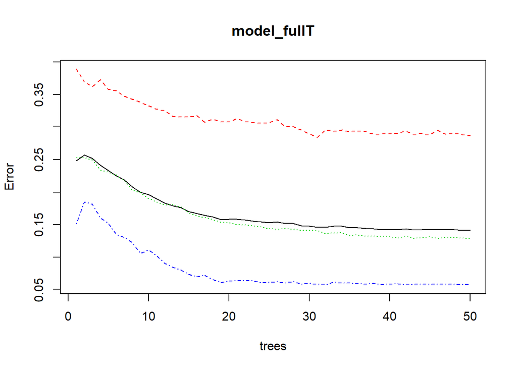

```r
plot(model_fullT)
```

```r
round(importance(model_fullT), 2)
```

```
##                                    MeanDecreaseGini
## rally                                         50.94
## speed                                        364.76
## net.clearance                                873.48
## distance.from.sideline                       229.95
## depth                                        312.66
## player.distance.travelled                    180.22
## player.impact.depth                          274.65
## player.impact.distance.from.center           110.26
## player.depth                                 137.44
## player.distance.from.center                   98.35
## previous.speed                               235.47
## previous.net.clearance                       147.22
## previous.distance.from.sideline              244.51
## previous.depth                               158.18
## opponent.depth                               199.90
## opponent.distance.from.center                108.50
## previous.time.to.net                         386.03
## serve                                         10.54
## hitpoint                                      38.10
## outside.sideline                             566.35
## outside.baseline                             347.10
## same.side                                      8.19
## previous.hitpoint                             49.41
## server.is.impact.player                        9.86
## gender                                        12.00
```

```r
pred_Train_fullT = predict(model_fullT,tennis_data[,setdiff(names(tennis_data),"outcome")],type="response", norm.votes=TRUE)
#pred_Train_fullT
cm_train_fullT = table("actual" = tennis_data$outcome, "predicted" = pred_Train_fullT);
accu_train_imp_fullT = sum(diag(cm_train_fullT))/sum(cm_train_fullT)
accu_train_imp_fullT
```

```
## [1] 0.999875
```

```r
pred_unseen_data_fullT = predict(model_fullT,unseen_data[,setdiff(names(unseen_data),"outcome")],type = "response", norm.votes=TRUE)
#pred_unseen_data_fullT
Pred_unseen_table_fullT = data.frame(pred_unseen_data_fullT)
write.table(Pred_unseen_table_fullT, file = "Pred_unseen_table_fullT.csv")
```